# Personal activity

boizette

22 septembre 2018

# R Markdown

## Introduction

This assignment makes uses of data from a personal activity monitoring device. The purpose is to provide a summary statistical description of the personal activity

## Data

The data are downloaded from the web site https://d396qusza40orc.cloudfront.net/ and the dataset contain 3 variables (collected from an anonymous individual collected during the months of October and Nomenber :

1. First variable= number of steps in a 5 minute interval
2. Second variable= the date on wich the measurement was taken
3. Third variable=identifier for the 5 minute interval on wich the measurement was taken

### Loading and preprocessing the data

```r
  download.file("https://d396qusza40orc.cloudfront.net/repdata%2Fdata%2Factivity.zip",destfile="activ.zip")
  unzip("activ.zip")
 obs<-read.csv("activity.csv",sep=",",header=TRUE)
 obs$date<-as.Date(obs$date)
print(paste("we obtain a dataset of",dim(obs)[1],"observations and",dim(obs)[2],"variables:"))
```

```
## [1] "we obtain a dataset of 17568 observations and 3 variables:"
```

### First chart: histogram of the total number of steps taken each day

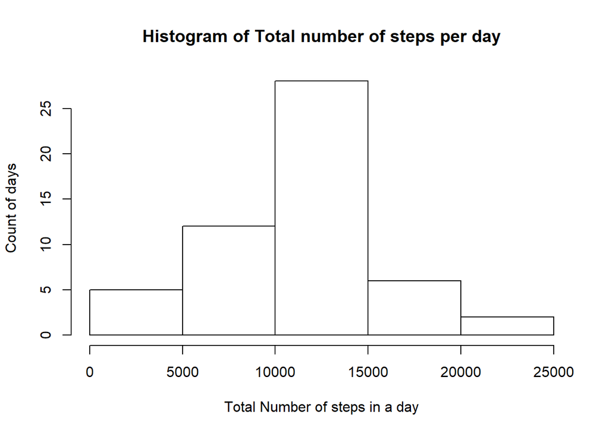

```r
h2<-obs[!is.na(obs$steps),]
library(dplyr)
j2<- h2 %>% group_by(date) %>% summarise(steps=sum(steps))
##j2$steps<-as.numeric(j2$steps)
library(ggplot2)
hist(j2$steps,xlab="Total Number of steps in a day",ylab="Count of days",main="Histogram of Total number of steps per day")
```

#### Report the mean and median of the total number of steps taken per day

```r
print(paste("the mean of the total number of steps taken per day is :",mean(j2$steps)))
```

```
## [1] "the mean of the total number of steps taken per day is : 10766.1886792453"
```

```r
print(paste("the median of the total number of steps taken per day is :",median(j2$steps)))
```

```
## [1] "the median of the total number of steps taken per day is : 10765"
```

### Second chart: Time series plot of the average daily number of steps

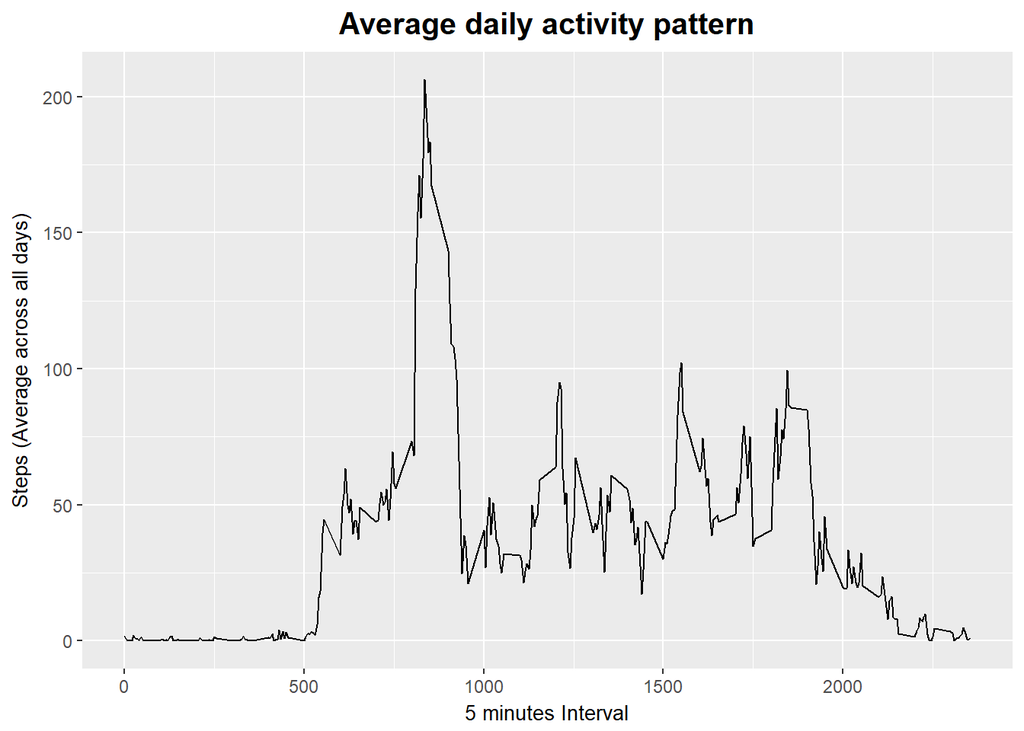

```r
j3<-h2 %>% group_by(interval) %>% summarise(steps=mean(steps))

ggplot(j3,aes(x=interval,y=steps),font.main=2)+geom_line()+ggtitle("Average daily activity pattern")+xlab("5 minutes Interval")+ylab("Steps (Average across all days)")+theme(plot.title=element_text(size=15,face="bold",hjust=0.5))+theme(axis.title=element_text(size=10))
```

#### Identification which 5 minute interval contains the maximum number of steps

```r
j3m<-max(j3$steps)
j3i<-j3$interval[j3$steps==j3m][1]
print(paste("the 5 minutes interval No",j3i,"contains the maximal number of steps"))
```

```
## [1] "the 5 minutes interval No 835 contains the maximal number of steps"
```